# Practice Session & Exercise

# 2 Practice across Sessions

## 2.1 Exercise 1: Environmental Monitoring Pipeline

You are an environmental data scientist processing seasonal weather anomalies. You need to read raw files, reshape and clean data, apply programmatic thresholds, isolate metrics using the apply family, generate analytical base R plots, and automatically compile everything into a professional HTML report.

For this project, you will use the airquality dataset, which is built directly into R. It tracks daily air quality measurements in New York, including solar radiation, wind, temperature, and ozone levels—factors that heavily influence biological ecosystems.

**Step 1: Data IO & Reshaping**

- Save the built-in R dataset to a temporary local CSV file on your hard drive using `write.csv()`.
- Read that exact file back into a new R variable named raw_env using `read.csv()`.
- Extract only rows matching the summer months of July and August into a filtered data frame called `summer_env`.

**Step 2: Loop Execution & Custom Control Flow**

- Write a `for` loop that iterates sequentially through every row of your `summer_env` data frame to check the `Temp` (Temperature) value for that day using an `if...else if...else` structure:
  - If Temp is strictly greater than 90°F, print: “Extreme Heat Detected ([Temp] degrees)”.
  - If Temp is between 80°F and 90°F (inclusive), print: “Moderate Warning”.
  - For all other temperatures, skip processing entirely using the `next` statement without printing anything.

**Step 3: High-Throughput Metrics via the `apply` Family**

- Use `apply` family function to find the min, maximum and standard deviation for `Temp` from the `summer_env`

**Step 4: Multi-Panel Visualizations with Base R Plots**

- Configure your R graphics engine using `par(mfrow = c(1, 2))` to arrange your upcoming plots side-by-side in a 1-row, 2-column grid.
- Plot 1: Draw a shaded `hist()` histogram of `summer_env$Temp`. Color it `"coral"`, add clear axis text, and label the title `"Summer Temperature Profile"`.
- Plot 2: Draw a `plot()` scatter plot showing Ozone on the y-axis and `Solar.R` (Solar Radiation) on the x-axis. Use solid circular indicators `(pch = 16)`, color the dots `"darkblue"`, and add a line of best fit through the plot utilizing `abline(lm(Ozone ~ Solar.R, data = summer_env), col = "red", lwd = 2)`.
- Reset your plotting layout back to standard single-panel parameters using `par(mfrow = c(1, 1))`.

**Step 5: Wrap it into an Automated HTML Report**

To practice modern literate programming as covered in our very first discussion, compile your steps into an automatically generated standalone HTML report document using Quarto (or R Markdown).

1. In RStudio, create a new document: File > New File > Quarto Document… (Select HTML output).
2. ipe out the default placeholder text and paste the complete solution script into clean execution code chunks.
3. Add professional Markdown headers (## Step 1…) between chunks to describe your analysis steps.
4. Click the Render (or Knit) button at the top of your screen to run the entire pipeline and generate your final report.html file automatically.

*Solution 27*.

```r
## --- STEP 1: DATA IO & RESHAPING ---
# Write built-in data out to file
write.csv(airquality, "temp_airquality.csv", row.names = FALSE)

# Read it back in
raw_env <- read.csv("temp_airquality.csv")


# Reshape/Filter for summer months (July = 7, August = 8)
summer_env <- raw_env[raw_env$Month == 7 | raw_env$Month == 8, ]



## --- STEP 2: LOOPS & CONTROL FLOW ---
for (i in 1:nrow(summer_env)) {
  current_temp <- summer_env$Temp[i]

  if (current_temp > 90) {
    print(paste("Row", i, ": Extreme Heat Detected (", current_temp, "degrees)"))
  } else if (current_temp >= 80 & current_temp <= 90) {
    print(paste("Row", i, ": Moderate Warning"))
  } else {
    next # Skip everything else safely
  }
}
```

```
[1] "Row 1 : Moderate Warning"
[1] "Row 2 : Moderate Warning"
[1] "Row 3 : Moderate Warning"
[1] "Row 4 : Moderate Warning"
[1] "Row 5 : Moderate Warning"
[1] "Row 6 : Moderate Warning"
[1] "Row 7 : Moderate Warning"
[1] "Row 8 : Extreme Heat Detected ( 92 degrees)"
[1] "Row 9 : Extreme Heat Detected ( 92 degrees)"
[1] "Row 10 : Moderate Warning"
[1] "Row 11 : Moderate Warning"
[1] "Row 13 : Moderate Warning"
[1] "Row 14 : Extreme Heat Detected ( 91 degrees)"
[1] "Row 15 : Moderate Warning"
[1] "Row 16 : Moderate Warning"
```

[output cut: 35 more lines]

```r
# --- STEP 3: THE APPLY FAMILY ---
tapply(summer_env$Temp, summer_env$Month, min)
```

```
 7  8
73 72
```

```r
tapply(summer_env$Temp, summer_env$Month, max)
```

```
 7  8
92 97
```

```r
tapply(summer_env$Temp, summer_env$Month, mean)
```

```
       7        8
83.90323 83.96774
```

```r
tapply(summer_env$Temp, summer_env$Month, sd)
```

```
       7        8
4.315513 6.585256
```

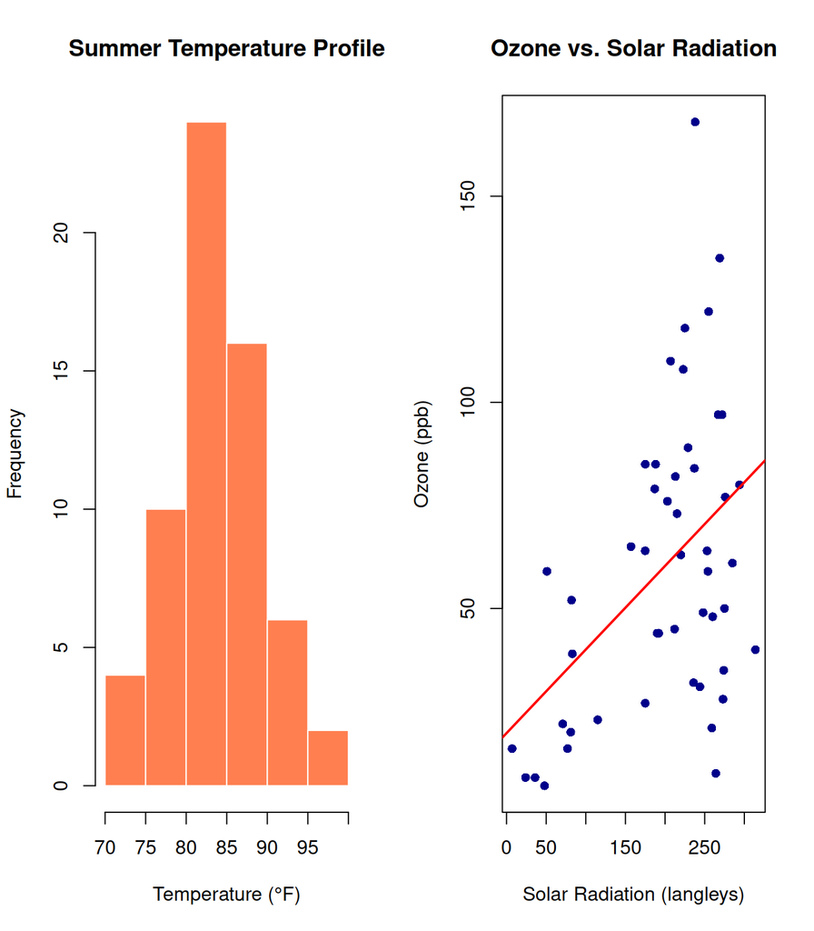

```r
# --- STEP 4: BASE R PLOTS ---
# Setup side-by-side canvas panels
par(mfrow = c(1, 2))

# Plot 1: Temperature Frequency Distribution
hist(summer_env$Temp,
     col = "coral",
     border = "white",
     main = "Summer Temperature Profile",
     xlab = "Temperature (°F)")

# Plot 2: Scatter plot tracking Solar influence on Ozone levels
plot(summer_env$Solar.R, summer_env$Ozone,
     pch = 16,
     col = "darkblue",
     main = "Ozone vs. Solar Radiation",
     xlab = "Solar Radiation (langleys)",
     ylab = "Ozone (ppb)")

# Overlay best fit linear regression path
abline(lm(Ozone ~ Solar.R, data = summer_env), col = "red", lwd = 2)
```

```r
# Reset graphic canvas parameters
par(mfrow = c(1, 1))
```

## 2.2 Exercise 2: Mini differential-expression pipeline

*Estimated time: 75 minutes (Phases A–C: ~45 min · Phase D + Bonus: ~30 min)*

This exercise ties together everything from Sessions 1–6. You will **save and reload** a small gene-expression dataset, **classify** genes by their fold change (control flow), **summarise** the groups two different ways (loop vs functional style), **reshape** the per-sample measurements, **merge** in sample metadata, **order** by biological importance, **round-trip** the result through CSV and RDS to see how the two formats differ, and finally **peek ahead** at visualisation.

**Setup — generate the two data frames in memory:**

```r
set.seed(2026)
genes <- paste0("g", 1:12)

# Per-gene baseline expression and treatment effect.
# Effects are a mix of up-regulation (+), down-regulation (-) and flat (~0)
# so the classification step later produces all three categories.
baseline <- round(rnorm(12, mean = 5, sd = 1), 2)
effect   <- c( 3.0,  2.5, -2.2, -1.6,  0.1, -0.2,
               2.8, -1.9,  0.3,  3.5, -2.0,  0.0)
noise <- function() round(rnorm(12, 0, 0.3), 2)

expr_wide <- data.frame(
  gene = genes,
  s1   = baseline           + noise(),  # ctrl
  s2   = baseline           + noise(),  # ctrl
  s3   = baseline + effect  + noise(),  # treat
  s4   = baseline + effect  + noise()   # treat
)

meta <- data.frame(
  sample_id = c("s1", "s2", "s3", "s4"),
  group     = c("ctrl", "ctrl", "treat", "treat")
)
```

The two objects `expr_wide` and `meta` now live in your R session. From here on, **you** are responsible for getting them onto disk and back.

### 2.2.1 Phase A — Read & Write

1. **Save** `expr_wide` and `meta` to disk as `expr_wide.csv` and `meta.csv`. **Read** them back into new objects `expr` and `meta_in`. (Since R 4.0, `read.csv()` keeps strings as character by default — no extra argument needed, but you may pass `stringsAsFactors = FALSE` for clarity.)
2. **Compute** a per-gene log2 fold change between the `treat` samples (`s3`, `s4`) and the `ctrl` samples (`s1`, `s2`). Hint: `log2(mean_treat / mean_ctrl)`. Store it as a new column `log2FC` in `expr`. Then run `hist(expr$log2FC)` — does the distribution suggest where the ±0.5 threshold should sit?

### 2.2.2 Phase B — Classify & Summarise

3. **Classify** each gene using `ifelse()` into one of three categories, stored in `expr$direction`:
   - `"up"` if `log2FC > 0.5`
   - `"down"` if `log2FC < -0.5`
   - `"flat"` otherwise

   Then run `barplot(table(expr$direction))` to verify you have genes in all three groups.
4. **Summarise the groups two different ways** so you can compare imperative vs functional R:
   1. Write a `for` loop that, for each direction in `c("up", "down", "flat")`, prints the number of genes and the mean `log2FC`.
   2. Reproduce the **same** summary in a single call using `tapply()` (or `sapply()` + subsetting). Confirm the numbers match.

### 2.2.3 Phase C — Reshape, Merge, Order

5. **Reshape** the four sample columns of `expr` from wide to long with `reshape()`, producing a data frame `long` with columns `gene`, `sample_id`, `expression`.
6. **Merge** `long` with `meta_in` by `sample_id` so each row also knows its `group`. Then merge in `log2FC` and `direction` from `expr` so every row carries its gene-level annotation. Run `boxplot(expression ~ group, data = long)` as a sanity check — can you already see the treatment effect?
7. **Order** the merged table by `abs(log2FC)` **descending** (most strongly affected genes first), then by `group`. This is the canonical ordering in differential-expression output.

### 2.2.4 Phase D — Save, Round-trip, Visualise

8. **Save** the final ordered table both as `results.csv` (text) and `results.rds` (binary). Read both back and compare each reload to the original using `identical()` *and* `all.equal()`. Which format round-trips exactly? Where does the other one differ (row order? row names? numeric precision? column types?).
9. **Peek at Session 5:** use `stripchart(expression ~ factor(direction, levels = c("down", "flat", "up")), data = long[long$group == "treat", ], vertical = TRUE, method = "jitter", pch = 19, col = c("tomato", "grey60", "steelblue"), main = "Treated samples: expression by direction")` to see the individual data points for each gene category. Do the `up` and `down` genes separate cleanly from the `flat` ones?

**Bonus Challenge:** Use `aggregate()` to compute the **standard deviation** of `expression` per `(gene, group)` pair on the long table. Which gene is the most variable inside the `treat` group? Does its `direction` (up/down/flat) explain that variability, or is something else going on?

*Solution 28*.

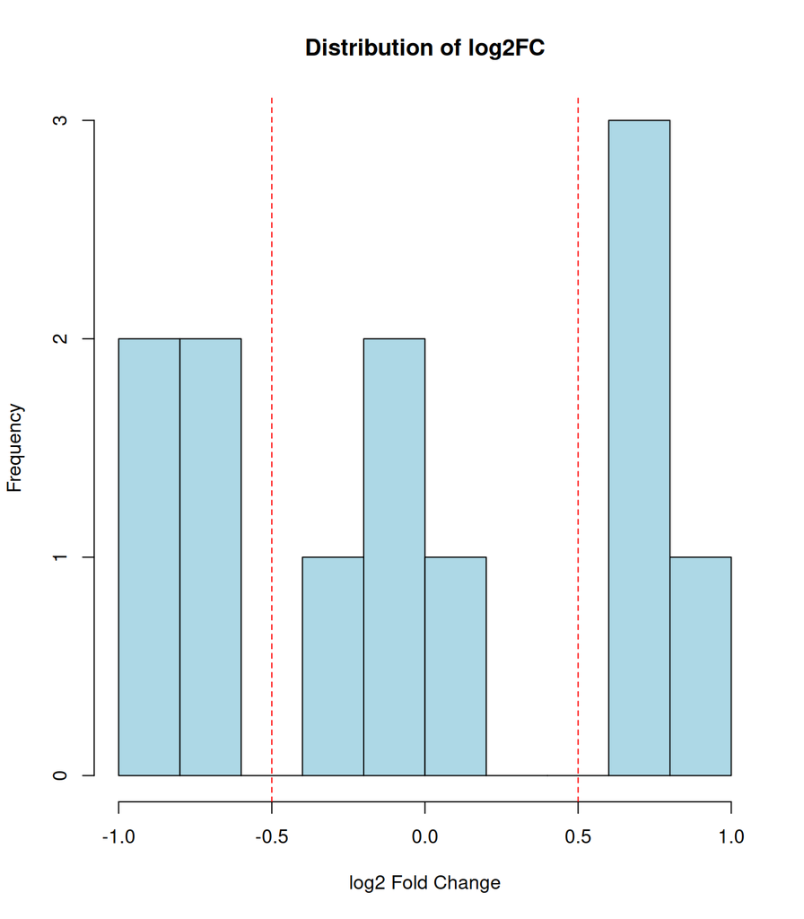

```r
# ---- Setup (same as in the task) ----
set.seed(2026)
genes <- paste0("g", 1:12)
baseline <- round(rnorm(12, mean = 5, sd = 1), 2)
effect   <- c( 3.0,  2.5, -2.2, -1.6,  0.1, -0.2,
               2.8, -1.9,  0.3,  3.5, -2.0,  0.0)
noise <- function() round(rnorm(12, 0, 0.3), 2)
expr_wide <- data.frame(
  gene = genes,
  s1 = baseline + noise(), s2 = baseline + noise(),
  s3 = baseline + effect + noise(), s4 = baseline + effect + noise()
)
meta <- data.frame(
  sample_id = c("s1", "s2", "s3", "s4"),
  group     = c("ctrl", "ctrl", "treat", "treat")
)

# ---- Phase A: Read & Write ----
# 1. Save and reload
write.csv(expr_wide, "expr_wide.csv", row.names = FALSE)
write.csv(meta,      "meta.csv",      row.names = FALSE)
expr    <- read.csv("expr_wide.csv")
meta_in <- read.csv("meta.csv")

# 2. log2 fold change (treat vs ctrl)
ctrl_mean  <- rowMeans(expr[, c("s1", "s2")])
treat_mean <- rowMeans(expr[, c("s3", "s4")])
expr$log2FC <- round(log2(treat_mean / ctrl_mean), 3)
hist(expr$log2FC, breaks = 8, main = "Distribution of log2FC",
     xlab = "log2 Fold Change", col = "lightblue")
abline(v = c(-0.5, 0.5), col = "red", lty = 2)  # show the thresholds
```

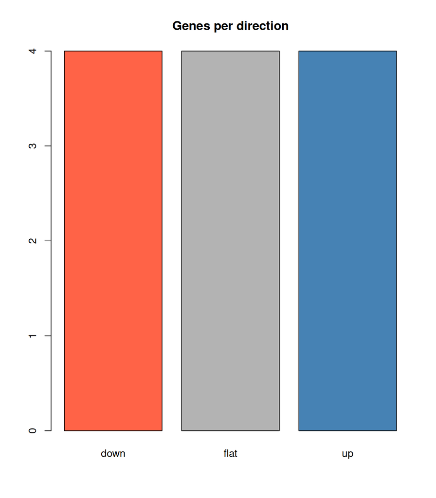

```r
# ---- Phase B: Classify & Summarise ----
# 3. Classify
expr$direction <- ifelse(expr$log2FC >  0.5, "up",
                  ifelse(expr$log2FC < -0.5, "down", "flat"))
barplot(table(expr$direction),
        main = "Genes per direction", col = c("tomato", "grey70", "steelblue"))
```

```r
# 4a. for-loop summary (imperative)
for (d in c("up", "down", "flat")) {
  sub <- expr[expr$direction == d, ]
  cat(d, ":", nrow(sub), "genes, mean log2FC =",
      round(mean(sub$log2FC), 3), "\n")
}
```

```
up : 4 genes, mean log2FC = 0.712
down : 4 genes, mean log2FC = -0.797
flat : 4 genes, mean log2FC = -0.121
```

```r
# 4b. Same summary in one shot (functional)
tapply(expr$log2FC, expr$direction, length)   # n genes
```

```
down flat   up
   4    4    4
```

```r
tapply(expr$log2FC, expr$direction, mean)     # mean log2FC
```

```
    down     flat       up
-0.79700 -0.12125  0.71175
```